# Stroke or myocardial infarction (heart attack)

# 1 Description of DataSchema variable

The description of harmonised variable is the following:

- Short name: `cvd_hard`
- Variable label: `History of stroke or myocardial infarction (heart attack)`
- Variable description: `The participant has been diagnosed by one or more of the following conditions: stroke or myocardial infarction or heart attack`
- Domain: `Diseases`
- Value type: `categorical`
- Category coding:

| **Code** | **Category Label** |
| --- | --- |
| 0 | no, the participant has not been diagnosed by stroke or myocardial infarction or heart attack |
| 1 | yes, no, the participant has been diagnosed by stroke or myocardial infarction or heart attack |

- Category missings:

| **Code** | **Category Label** |
| --- | --- |
| 991 | CAPI/interviewer error |
| 992 | Impute |
| 993 | Disable to measure |
| 994 | Not attempt/not done |
| 995 | Does not answer |
| 996 | Not applicable |
| 997 | Refuse |
| 998 | Do not know |
| 999 | Missing |

# 2 Data process

## 2.1 England

### 2.1.1 Wave 1

#### 2.1.1.1 Study-specific variable description

| **Name** | `mi_ha` | `stroke` |
| --- | --- | --- |
| **Label** | `Myocardial infarction or heart attack` | `Stroke` |
| **Table name** | `mi_ha` | `stroke` |
| **Categories** | `0 = No` `1 = Yes` | `0 = NOT A stroke (cerebral vascular disease)` `1 = A stroke (cerebral vascular disease)` |
| **Missings** | `997 = Refuse` `998 = Do not know` | `997 = Refuse` `998 = Do not know` |
| **Description** |  |  |

mi_ha

| Sample size | Missing values |
| --- | --- |
| 12099 | 9 |

Category

|  | 0 | 1 |
| --- | --- | --- |
| Frequency | 11388.00 | 702.0 |
| Percentage | 94.12 | 5.8 |

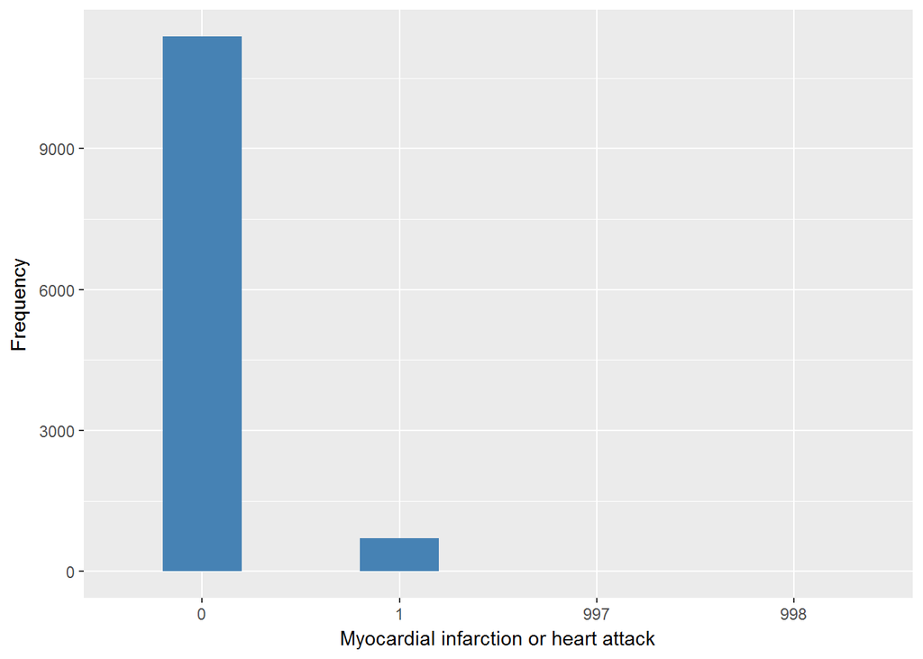

stroke

| Sample size | Missing values |
| --- | --- |
| 12099 | 9 |

Category

|  | 0 | 1 |
| --- | --- | --- |
| Frequency | 11574.00 | 516.00 |
| Percentage | 95.66 | 4.26 |

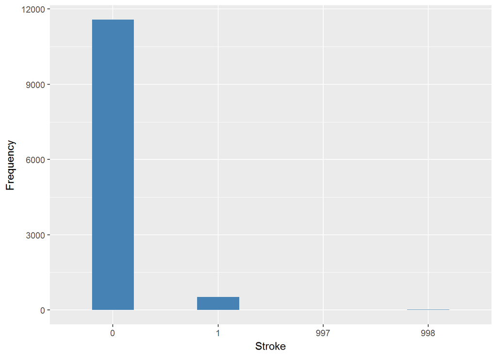

#### 2.1.1.2 Harmonisation algorithm

To compute `cvd_hard` from the study-specific variable it has to be recoded as follows:

- `mi_ha == 1 or stroke == 1 into 1`
- `997 into 997`
- `998 into 998`
- `otherwise into 0`

**R script:**

```r
# Categorical variable harmonization
ELSA_ds_w1 <- tibble(id = ELSA_w1$id)
ELSA_ds_w1$cvd_hard <- rep(0, length(ELSA_w1$id))
ELSA_ds_w1$cvd_hard[which(ELSA_w1$mi_ha == 1 | ELSA_w1$stroke == 1)] <- 1
ELSA_ds_w1$cvd_hard[which(ELSA_w1$mi_ha == 997)] <- 997
ELSA_ds_w1$cvd_hard[which(ELSA_w1$mi_ha == 998)] <- 998
```

#### 2.1.1.3 Statistics of the new harmonized variable

History of stroke or myocardial infarction (heart attack)

| Sample size | Missing values |
| --- | --- |
| 12099 | 9 |

Category

|  | 0 | 1 |
| --- | --- | --- |
| Frequency | 10981.00 | 1109.00 |
| Percentage | 90.76 | 9.17 |

Type of missing

|  | 991 | 992 | 993 | 994 | 995 | 996 | 997 | 998 | 999 | NA |
| --- | --- | --- | --- | --- | --- | --- | --- | --- | --- | --- |
| Frequency | 0 | 0 | 0 | 0 | 0 | 0 | 3.00 | 6.00 | 0 | 0 |
| Percentage | 0 | 0 | 0 | 0 | 0 | 0 | 0.02 | 0.05 | 0 | 0 |

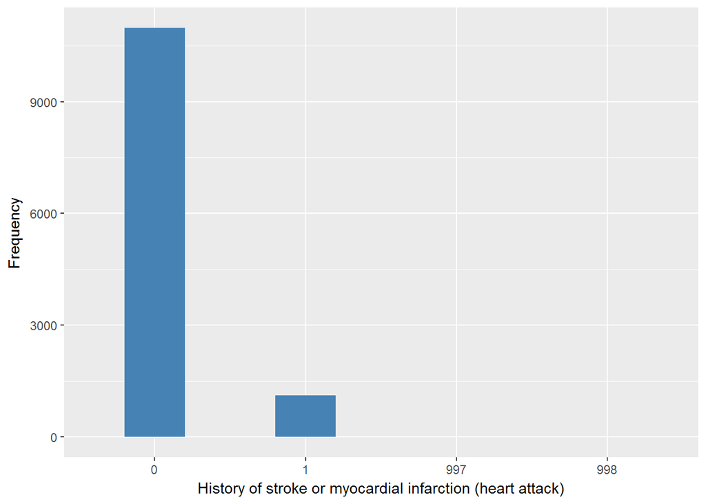

#### 2.1.1.4 Validation

|  | all 0->0 | some 1->1 | 997->997 | 998->998 |
| --- | --- | --- | --- | --- |
| BeforeH | 10981 | 1109 | 3 | 6 |
| AfterH | 10981 | 1109 | 3 | 6 |

### 2.1.2 Wave 2

#### 2.1.2.1 Study-specific variable description

| **Name** | `mi_ha` | `stroke` |  |
| --- | --- | --- | --- |
| **Label** | `Myocardial infarction or heart attack` | `Stroke` |  |
| **Table name** | `mi_ha` | `stroke` |  |
| **Categories** | `0 = No` `1 = Yes` | `0 = NOT A stroke (cerebral vascular disease)` `1 = A stroke (cerebral vascular disease)` |  |
| **Missings** | `997 = Refuse` `998 = Do not know` | `997 = Refuse` `998 = Do not know` |  |
| **Description** |  |  |  |

mi_ha

| Sample size | Missing values |
| --- | --- |
| 9432 | 9 |

Category

|  | 0 | 1 |
| --- | --- | --- |
| Frequency | 9291.00 | 132.0 |
| Percentage | 98.51 | 1.4 |

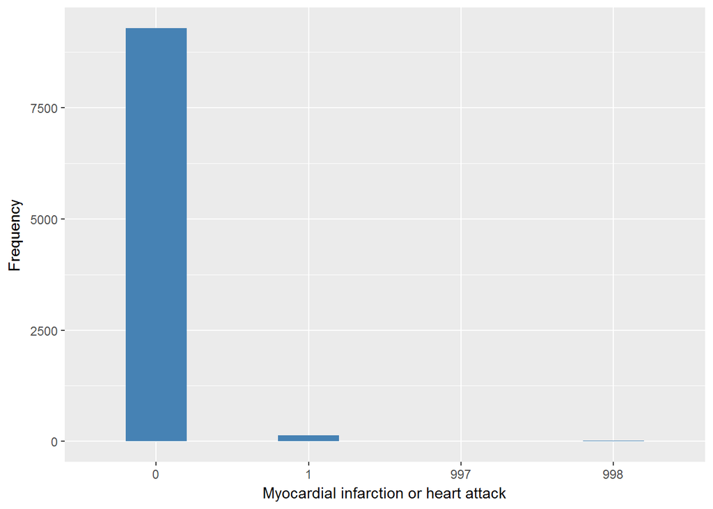

stroke

| Sample size | Missing values |
| --- | --- |
| 9432 | 9 |

Category

|  | 0 | 1 |
| --- | --- | --- |
| Frequency | 9253.0 | 170.0 |
| Percentage | 98.1 | 1.8 |

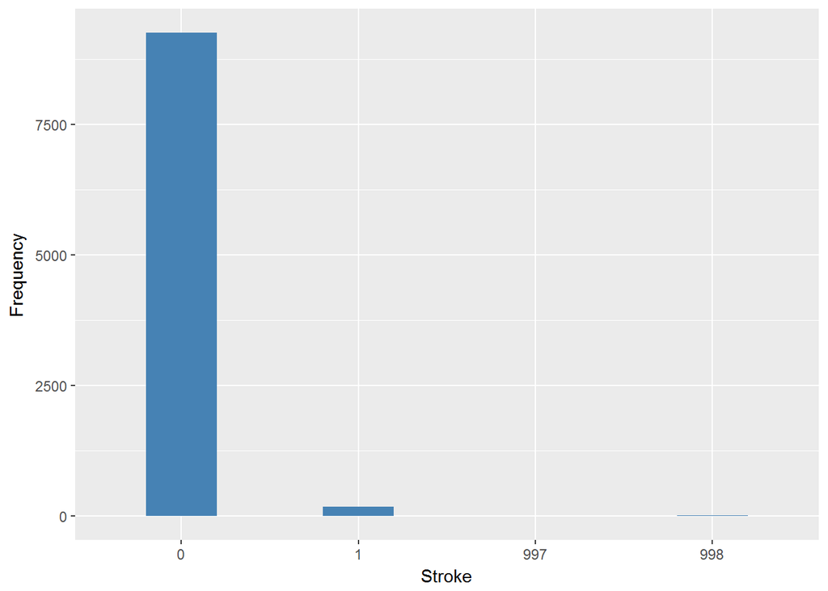

#### 2.1.2.2 Harmonisation algorithm

To compute `cvd_hard` from the study-specific variable it has to be recoded as follows:

- `mi_ha == 1 or stroke == 1 into 1`
- `997 into 997`
- `998 into 998`
- `otherwise into 0`

**R script:**

```r
# Categorical variable harmonization
ELSA_ds_w2 <- tibble(id = ELSA_w2$id)
ELSA_ds_w2$cvd_hard <- rep(0, length(ELSA_w2$id))
ELSA_ds_w2$cvd_hard[which(ELSA_w2$mi_ha == 1 | ELSA_w2$stroke == 1)] <- 1
ELSA_ds_w2$cvd_hard[which(ELSA_w2$mi_ha == 997 & ELSA_w2$stroke == 997)] <- 997
ELSA_ds_w2$cvd_hard[which(ELSA_w2$mi_ha == 998 & ELSA_w2$stroke == 998)] <- 998
```

#### 2.1.2.3 Statistics of the new harmonized variable

History of stroke or myocardial infarction (heart attack)

| Sample size | Missing values |
| --- | --- |
| 9432 | 9 |

Category

|  | 0 | 1 |
| --- | --- | --- |
| Frequency | 9129.00 | 294.00 |
| Percentage | 96.79 | 3.12 |

Type of missing

|  | 991 | 992 | 993 | 994 | 995 | 996 | 997 | 998 | 999 | NA |
| --- | --- | --- | --- | --- | --- | --- | --- | --- | --- | --- |
| Frequency | 0 | 0 | 0 | 0 | 0 | 0 | 1.00 | 8.00 | 0 | 0 |
| Percentage | 0 | 0 | 0 | 0 | 0 | 0 | 0.01 | 0.08 | 0 | 0 |

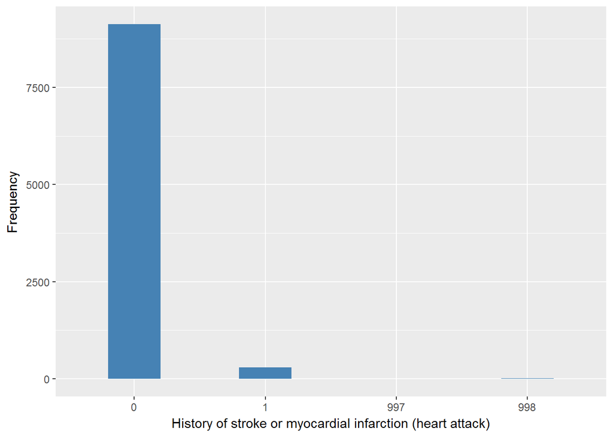

#### 2.1.2.4 Validation

|  | all 0->0 | some 1->1 | 997->997 | 998->998 |
| --- | --- | --- | --- | --- |
| BeforeH | 9129 | 294 | 1 | 8 |
| AfterH | 9129 | 294 | 1 | 8 |

### 2.1.3 Wave 3

#### 2.1.3.1 Study-specific variable description

| **Name** | `mi_ha` | `stroke` |
| --- | --- | --- |
| **Label** | `Myocardial infarction or heart attack` | `Stroke` |
| **Table name** | `mi_ha` | `stroke` |
| **Categories** | `0 = No` `1 = Yes` | `0 = NOT A stroke (cerebral vascular disease)` `1 = A stroke (cerebral vascular disease)` |
| **Missings** | `996 = Not applicable` | `996 = Not applicable` |
| **Description** |  |  |

mi_ha

| Sample size | Missing values |
| --- | --- |
| 9771 | 5 |

Category

|  | 0 | 1 |
| --- | --- | --- |
| Frequency | 9655.00 | 111.00 |
| Percentage | 98.81 | 1.14 |

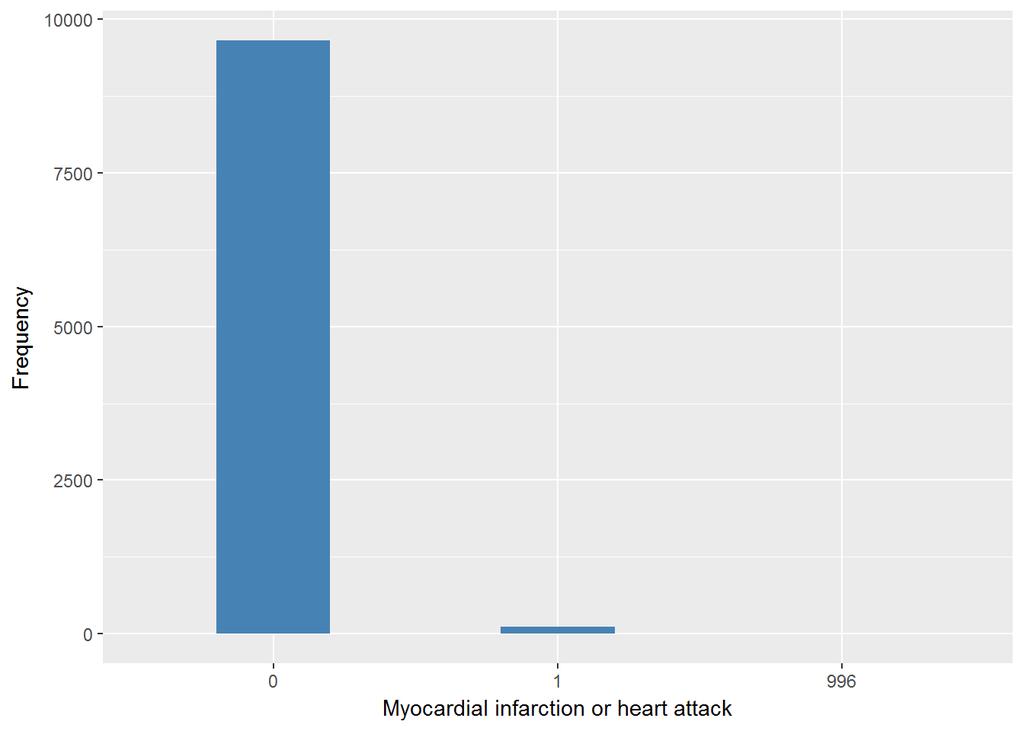

stroke

| Sample size | Missing values |
| --- | --- |
| 9771 | 5 |

Category

|  | 0 | 1 |
| --- | --- | --- |
| Frequency | 9655.00 | 111.00 |
| Percentage | 98.81 | 1.14 |

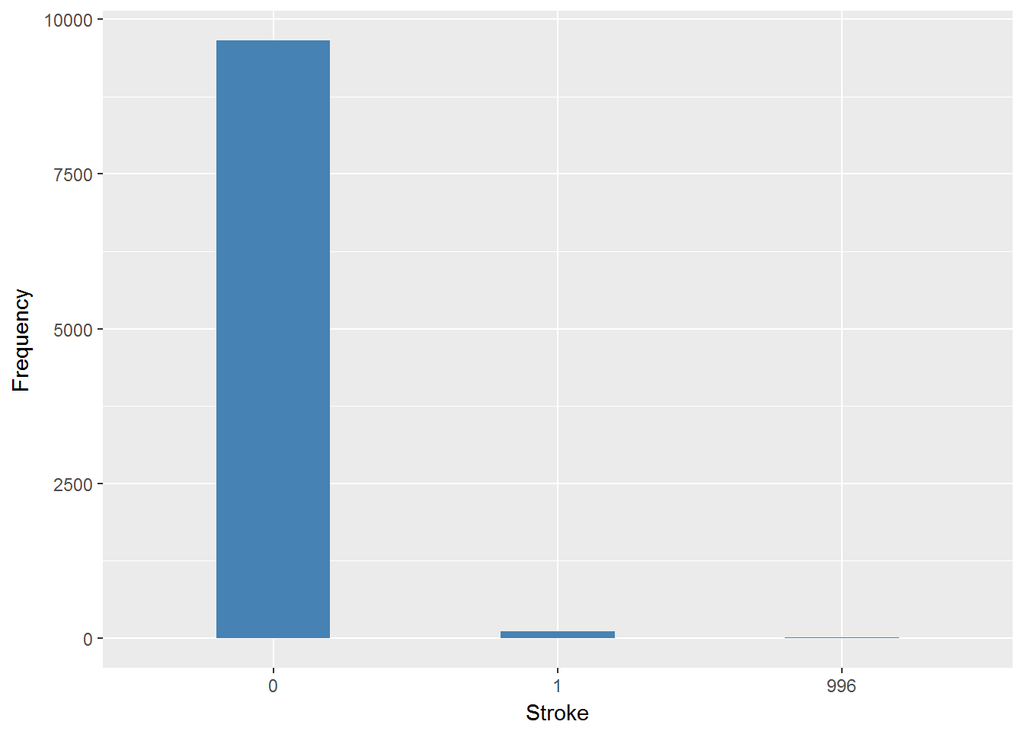

#### 2.1.3.2 Harmonisation algorithm

To compute `cvd_hard` from the study-specific variable it has to be recoded as follows:

- `some 1 into 1`
- `all 0 into 0`
- `996 into 996`

**R script:**

```r
# Categorical variable harmonization
ELSA_ds_w3 <- tibble(id = ELSA_w3$id)
ELSA_ds_w3$cvd_hard <- rep(999, length(ELSA_w3$id))
ELSA_ds_w3$cvd_hard[which(ELSA_w3$mi_ha == 0 & ELSA_w3$stroke == 0)] <- 0
ELSA_ds_w3$cvd_hard[which(ELSA_w3$mi_ha == 1 | ELSA_w3$stroke == 1)] <- 1
ELSA_ds_w3$cvd_hard[which(ELSA_w3$mi_ha == 996 & ELSA_w3$stroke == 996)] <- 996
```

#### 2.1.3.3 Statistics of the new harmonized variable

History of stroke or myocardial infarction (heart attack)

| Sample size | Missing values |
| --- | --- |
| 9771 | 5 |

Category

|  | 0 | 1 |
| --- | --- | --- |
| Frequency | 9551.00 | 215.0 |
| Percentage | 97.75 | 2.2 |

Type of missing

|  | 991 | 992 | 993 | 994 | 995 | 996 | 997 | 998 | 999 | NA |
| --- | --- | --- | --- | --- | --- | --- | --- | --- | --- | --- |
| Frequency | 0 | 0 | 0 | 0 | 0 | 5.00 | 0 | 0 | 0 | 0 |
| Percentage | 0 | 0 | 0 | 0 | 0 | 0.05 | 0 | 0 | 0 | 0 |

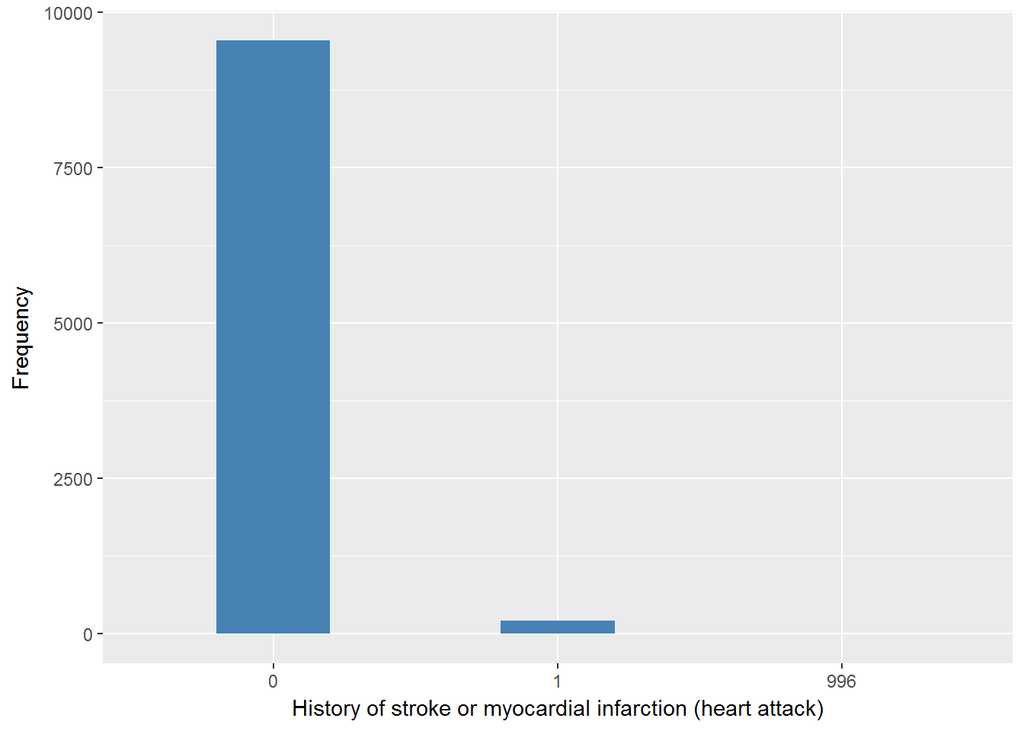

#### 2.1.3.4 Validation

|  | all 0->0 | some 1->1 | 996->996 |
| --- | --- | --- | --- |
| BeforeH | 9551 | 215 | 5 |
| AfterH | 9551 | 215 | 5 |

### 2.1.4 Wave 4

#### 2.1.4.1 Study-specific variable description

| **Name** | `mi_ha` | `stroke` |
| --- | --- | --- |
| **Label** | `Myocardial infarction or heart attack` | `Stroke` |
| **Table name** | `mi_ha` | `stroke` |
| **Categories** | `0 = No` `1 = Yes` | `0 = NOT A stroke (cerebral vascular disease)` `1 = A stroke (cerebral vascular disease)` |
| **Missings** | `997 = Refuse` `998 = Do not know` | `997 = Refuse` `998 = Do not know` |
| **Description** |  |  |

mi_ha

| Sample size | Missing values |
| --- | --- |
| 11050 | 16 |

Category

|  | 0 | 1 |
| --- | --- | --- |
| Frequency | 10894.00 | 140.00 |
| Percentage | 98.59 | 1.27 |

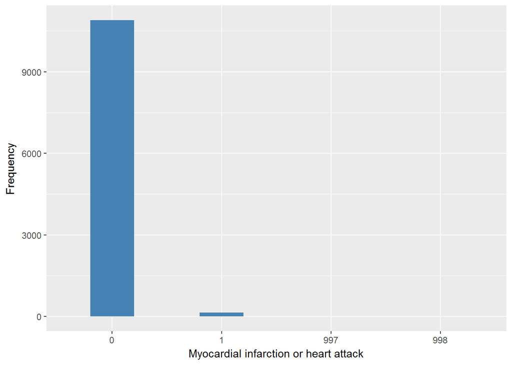

stroke

| Sample size | Missing values |
| --- | --- |
| 11050 | 16 |

Category

|  | 0 | 1 |
| --- | --- | --- |
| Frequency | 10851.0 | 183.00 |
| Percentage | 98.2 | 1.66 |

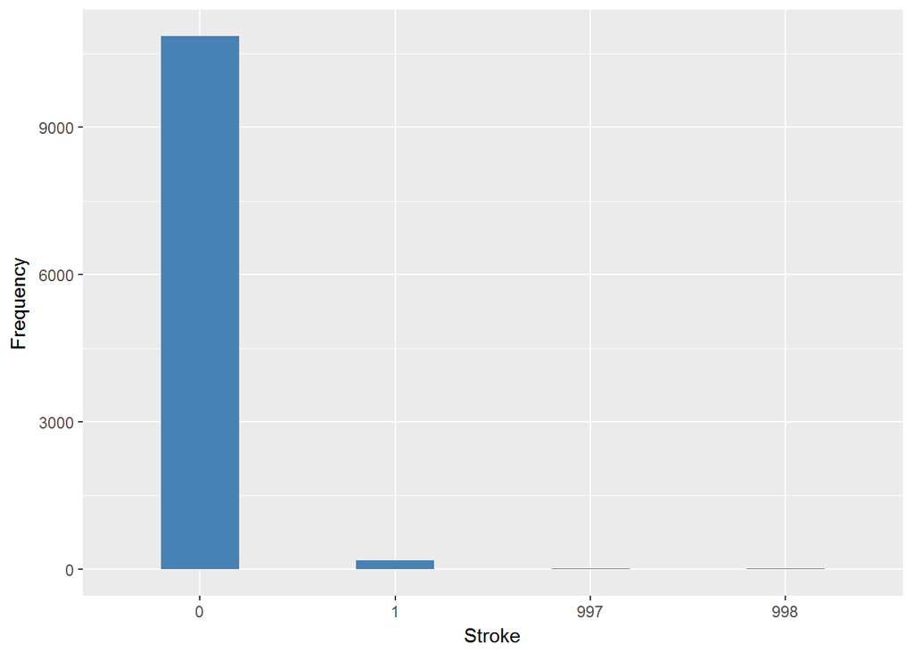

#### 2.1.4.2 Harmonisation algorithm

To compute `cvd_hard` from the study-specific variable it has to be recoded as follows:

- `some 1 into 1`
- `all 0 into 0`
- `997 into 997`
- `998 into 998`

**R script:**

```r
# Categorical variable harmonization
ELSA_ds_w4 <- tibble(id = ELSA_w4$id)
ELSA_ds_w4$cvd_hard <- rep(999, length(ELSA_w4$id))
ELSA_ds_w4$cvd_hard[which(ELSA_w4$mi_ha == 0 & ELSA_w4$stroke == 0)] <- 0
ELSA_ds_w4$cvd_hard[which(ELSA_w4$mi_ha == 1 | ELSA_w4$stroke == 1)] <- 1
ELSA_ds_w4$cvd_hard[which(ELSA_w4$mi_ha == 998 & ELSA_w4$stroke == 998)] <- 998
ELSA_ds_w4$cvd_hard[which(ELSA_w4$mi_ha == 997 & ELSA_w4$stroke == 997)] <- 997
```

#### 2.1.4.3 Statistics of the new harmonized variable

History of stroke or myocardial infarction (heart attack)

| Sample size | Missing values |
| --- | --- |
| 11050 | 16 |

Category

|  | 0 | 1 |
| --- | --- | --- |
| Frequency | 10726.00 | 308.00 |
| Percentage | 97.07 | 2.79 |

Type of missing

|  | 991 | 992 | 993 | 994 | 995 | 996 | 997 | 998 | 999 | NA |
| --- | --- | --- | --- | --- | --- | --- | --- | --- | --- | --- |
| Frequency | 0 | 0 | 0 | 0 | 0 | 0 | 7.00 | 9.00 | 0 | 0 |
| Percentage | 0 | 0 | 0 | 0 | 0 | 0 | 0.06 | 0.08 | 0 | 0 |

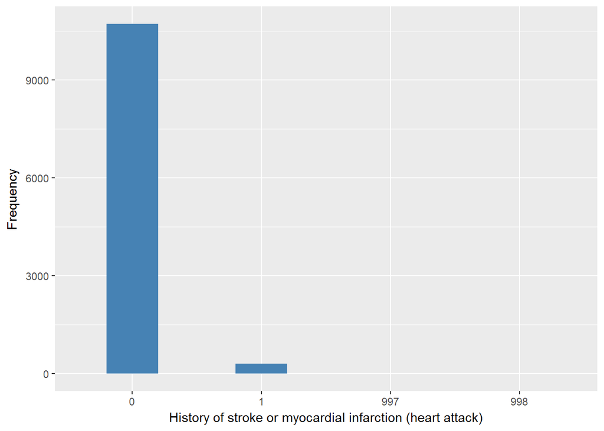

#### 2.1.4.4 Validation

|  | all 0->0 | some 1->1 | 997->997 | 998->998 |
| --- | --- | --- | --- | --- |
| BeforeH | 10726 | 308 | 7 | 9 |
| AfterH | 10726 | 308 | 7 | 9 |

### 2.1.5 Wave 5

#### 2.1.5.1 Study-specific variable description

| **Name** | `mi_ha` | `stroke` |
| --- | --- | --- |
| **Label** | `Myocardial infarction or heart attack` | `Stroke` |
| **Table name** | `mi_ha` | `stroke` |
| **Categories** | `0 = No` `1 = Yes` | `0 = NOT A stroke (cerebral vascular disease)` `1 = A stroke (cerebral vascular disease)` |
| **Missings** | `997 = Refuse` `998 = Do not know` | `997 = Refuse` `998 = Do not know` |
| **Description** |  |  |

mi_ha

| Sample size | Missing values |
| --- | --- |
| 10274 | 15 |

Category

|  | 0 | 1 |
| --- | --- | --- |
| Frequency | 10137.00 | 122.00 |
| Percentage | 98.67 | 1.19 |

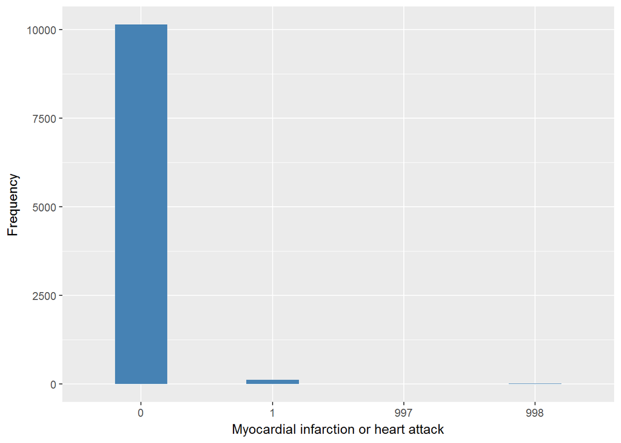

stroke

| Sample size | Missing values |
| --- | --- |
| 10274 | 15 |

Category

|  | 0 | 1 |
| --- | --- | --- |
| Frequency | 10110.0 | 149.00 |
| Percentage | 98.4 | 1.45 |

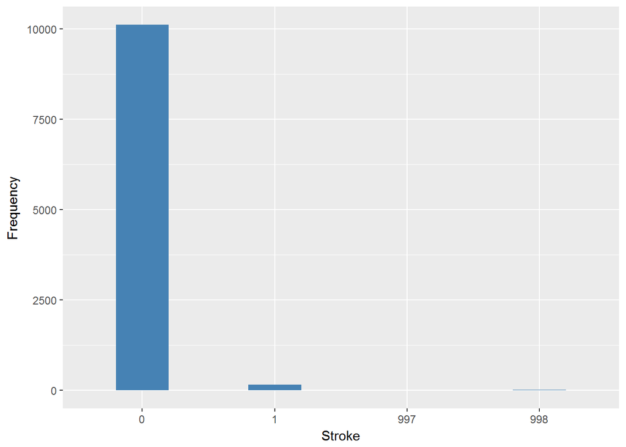

#### 2.1.5.2 Harmonisation algorithm

To compute `cvd_hard` from the study-specific variable it has to be recoded as follows:

- `some 1 into 1`
- `all 0 into 0`
- `997 into 997`
- `998 into 998`

**R script:**

```r
# Categorical variable harmonization
ELSA_ds_w5 <- tibble(id = ELSA_w5$id)
ELSA_ds_w5$cvd_hard <- rep(999, length(ELSA_w5$id))
ELSA_ds_w5$cvd_hard[which(ELSA_w5$mi_ha == 0 & ELSA_w5$stroke == 0)] <- 0
ELSA_ds_w5$cvd_hard[which(ELSA_w5$mi_ha == 1 | ELSA_w5$stroke == 1)] <- 1
ELSA_ds_w5$cvd_hard[which(ELSA_w5$mi_ha == 998 & ELSA_w5$stroke == 998)] <- 998
ELSA_ds_w5$cvd_hard[which(ELSA_w5$mi_ha == 997 & ELSA_w5$stroke == 997)] <- 997
```

#### 2.1.5.3 Statistics of the new harmonized variable

History of stroke or myocardial infarction (heart attack)

| Sample size | Missing values |
| --- | --- |
| 10274 | 15 |

Category

|  | 0 | 1 |
| --- | --- | --- |
| Frequency | 10002.00 | 257.0 |
| Percentage | 97.35 | 2.5 |

Type of missing

|  | 991 | 992 | 993 | 994 | 995 | 996 | 997 | 998 | 999 | NA |
| --- | --- | --- | --- | --- | --- | --- | --- | --- | --- | --- |
| Frequency | 0 | 0 | 0 | 0 | 0 | 0 | 4.00 | 11.00 | 0 | 0 |
| Percentage | 0 | 0 | 0 | 0 | 0 | 0 | 0.04 | 0.11 | 0 | 0 |

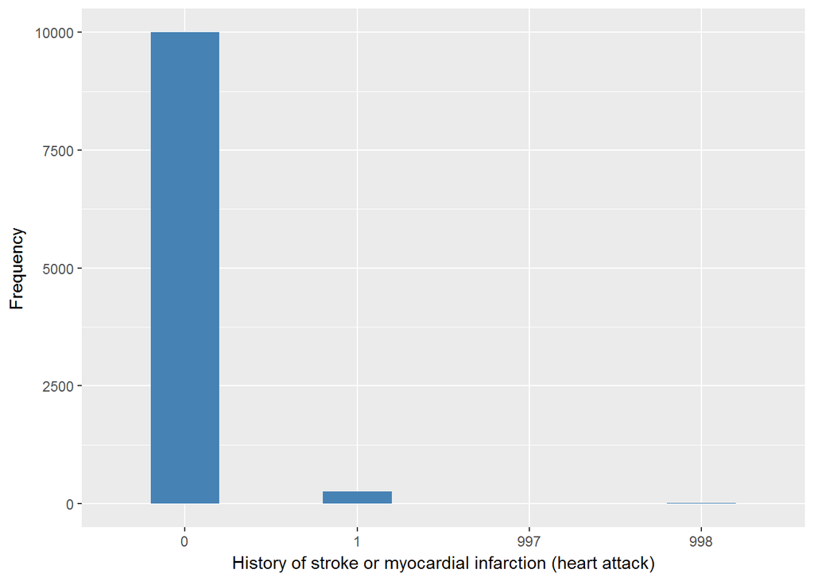

#### 2.1.5.4 Validation

|  | all 0->0 | some 1->1 | 997->997 | 998->998 |
| --- | --- | --- | --- | --- |
| BeforeH | 10002 | 257 | 4 | 11 |
| AfterH | 10002 | 257 | 4 | 11 |

### 2.1.6 Wave 6

#### 2.1.6.1 Study-specific variable description

| **Name** | `mi_ha` | `stroke` |
| --- | --- | --- |
| **Label** | `Myocardial infarction or heart attack` | `Stroke` |
| **Table name** | `mi_ha` | `stroke` |
| **Categories** | `0 = No` `1 = Yes` | `0 = NOT A stroke (cerebral vascular disease)` `1 = A stroke (cerebral vascular disease)` |
| **Missings** | `997 = Refuse` `998 = Do not know` | `997 = Refuse` `998 = Do not know` |
| **Description** |  |  |

mi_ha

| Sample size | Missing values |
| --- | --- |
| 10601 | 11 |

Category

|  | 0 | 1 |
| --- | --- | --- |
| Frequency | 10462.00 | 128.00 |
| Percentage | 98.69 | 1.21 |

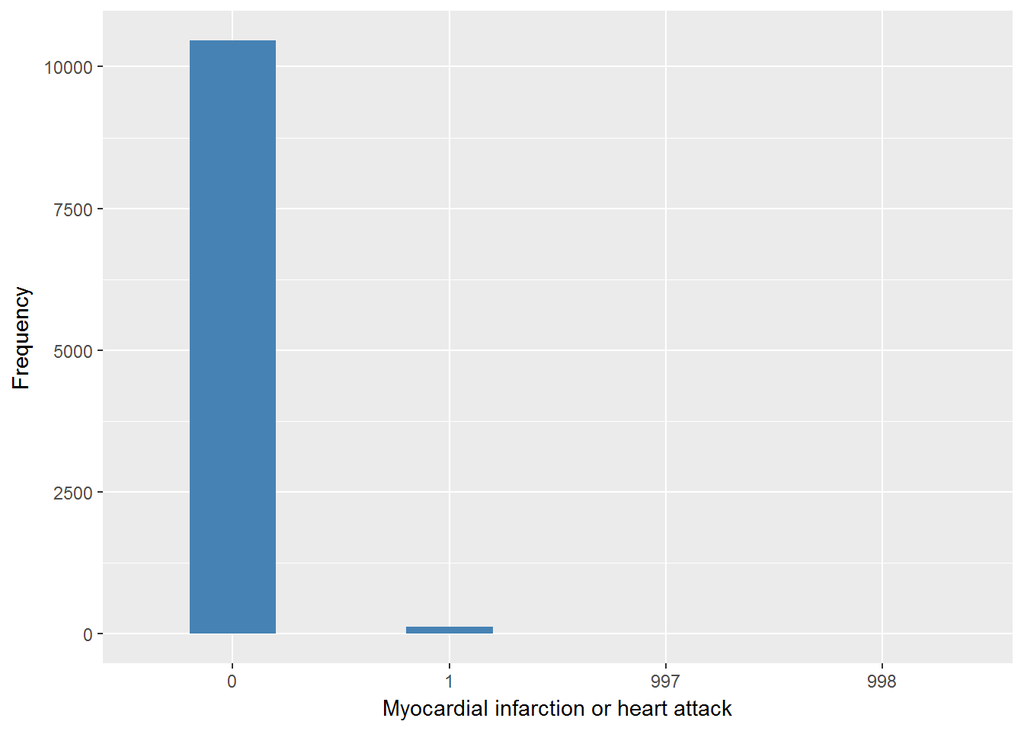

stroke

| Sample size | Missing values |
| --- | --- |
| 10601 | 11 |

Category

|  | 0 | 1 |
| --- | --- | --- |
| Frequency | 10432.00 | 158.00 |
| Percentage | 98.41 | 1.49 |

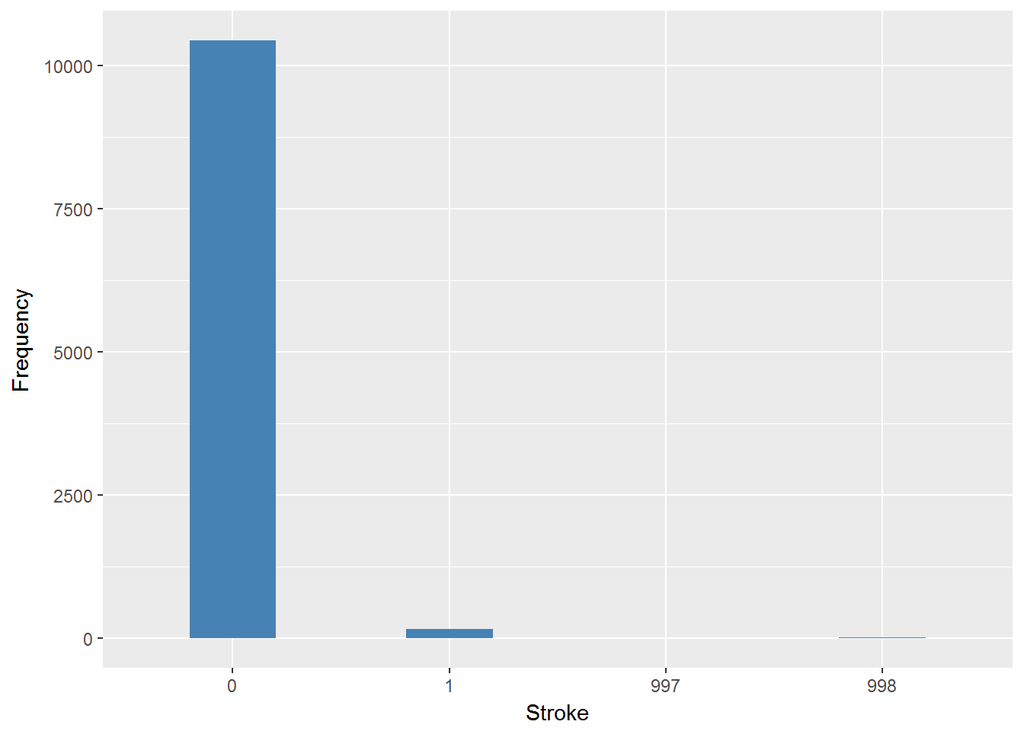

#### 2.1.6.2 Harmonisation algorithm

To compute `cvd_hard` from the study-specific variable it has to be recoded as follows:

- `some 1 into 1`
- `all 0 into 0`
- `997 into 997`
- `998 into 998`

**R script:**

```r
# Categorical variable harmonization
ELSA_ds_w6 <- tibble(id = ELSA_w6$id)
ELSA_ds_w6$cvd_hard <- rep(999, length(ELSA_w6$id))
ELSA_ds_w6$cvd_hard[which(ELSA_w6$mi_ha == 0 & ELSA_w6$stroke == 0)] <- 0
ELSA_ds_w6$cvd_hard[which(ELSA_w6$mi_ha == 1 | ELSA_w6$stroke == 1)] <- 1
ELSA_ds_w6$cvd_hard[which(ELSA_w6$mi_ha == 998 & ELSA_w6$stroke == 998)] <- 998
ELSA_ds_w6$cvd_hard[which(ELSA_w6$mi_ha == 997 & ELSA_w6$stroke == 997)] <- 997
```

#### 2.1.6.3 Statistics of the new harmonized variable

History of stroke or myocardial infarction (heart attack)

| Sample size | Missing values |
| --- | --- |
| 10601 | 11 |

Category

|  | 0 | 1 |
| --- | --- | --- |
| Frequency | 10323.00 | 267.00 |
| Percentage | 97.38 | 2.52 |

Type of missing

|  | 991 | 992 | 993 | 994 | 995 | 996 | 997 | 998 | 999 | NA |
| --- | --- | --- | --- | --- | --- | --- | --- | --- | --- | --- |
| Frequency | 0 | 0 | 0 | 0 | 0 | 0 | 4.00 | 7.00 | 0 | 0 |
| Percentage | 0 | 0 | 0 | 0 | 0 | 0 | 0.04 | 0.07 | 0 | 0 |

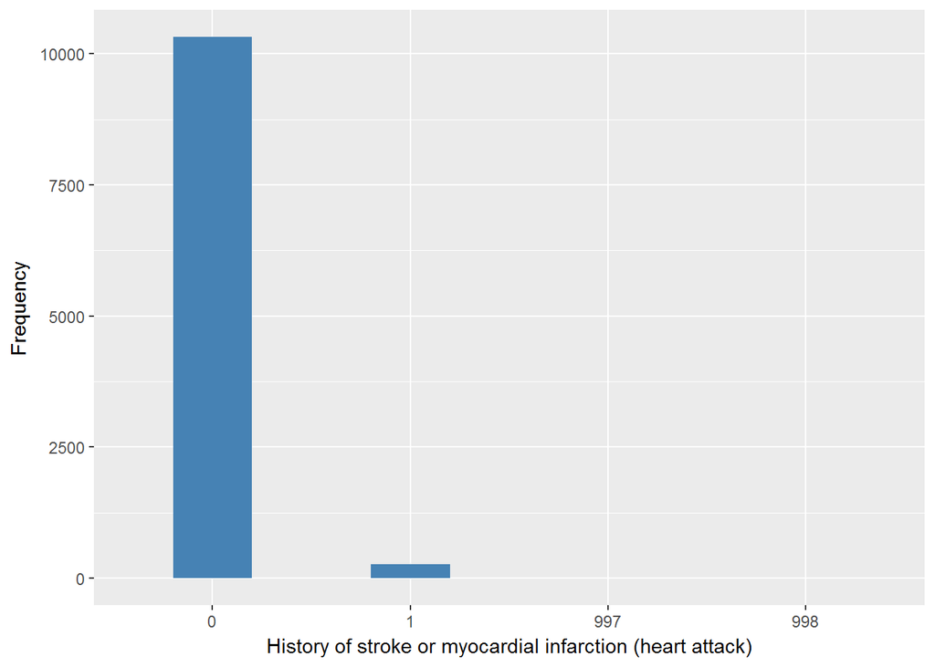

#### 2.1.6.4 Validation

|  | all 0->0 | some 1->1 | 997->997 | 998->998 |
| --- | --- | --- | --- | --- |
| BeforeH | 10323 | 267 | 4 | 7 |
| AfterH | 10323 | 267 | 4 | 7 |

### 2.1.7 Wave 7

#### 2.1.7.1 Study-specific variable description

| **Name** | `mi_ha` | `stroke` |
| --- | --- | --- |
| **Label** | `Myocardial infarction or heart attack` | `Stroke` |
| **Table name** | `mi_ha` | `stroke` |
| **Categories** | `0 = No` `1 = Yes` | `0 = NOT A stroke (cerebral vascular disease)` `1 = A stroke (cerebral vascular disease)` |
| **Missings** | `997 = Refuse` `998 = Do not know` | `997 = Refuse` `998 = Do not know` |
| **Description** |  |  |

mi_ha

| Sample size | Missing values |
| --- | --- |
| 9666 | 6 |

Category

|  | 0 | 1 |
| --- | --- | --- |
| Frequency | 9554.00 | 106.0 |
| Percentage | 98.84 | 1.1 |

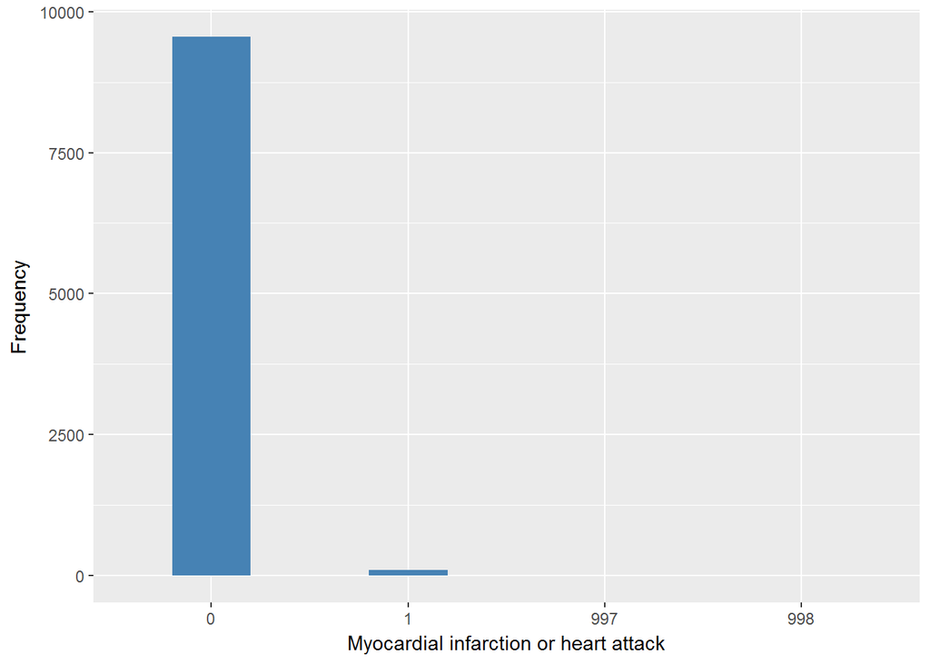

stroke

| Sample size | Missing values |
| --- | --- |
| 9666 | 6 |

Category

|  | 0 | 1 |
| --- | --- | --- |
| Frequency | 9522.00 | 138.00 |
| Percentage | 98.51 | 1.43 |

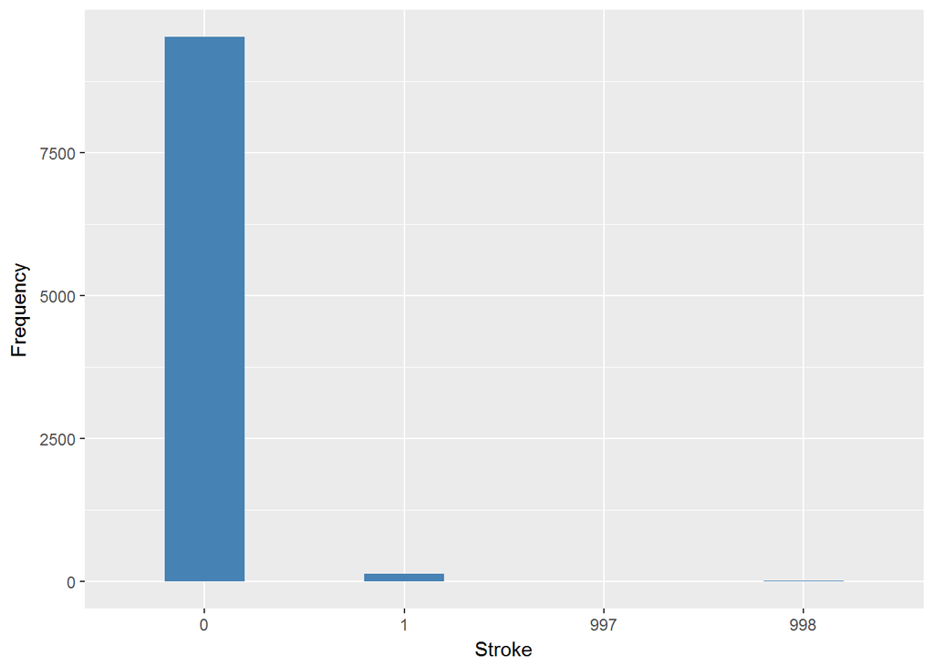

#### 2.1.7.2 Harmonisation algorithm

To compute `cvd_hard` from the study-specific variable it has to be recoded as follows:

- `some 1 into 1`
- `all 0 into 0`
- `997 into 997`
- `998 into 998`

**R script:**

```r
# Categorical variable harmonization
ELSA_ds_w7 <- tibble(id = ELSA_w7$id)
ELSA_ds_w7$cvd_hard <- rep(999, length(ELSA_w7$id))
ELSA_ds_w7$cvd_hard[which(ELSA_w7$mi_ha == 0 & ELSA_w7$stroke == 0)] <- 0
ELSA_ds_w7$cvd_hard[which(ELSA_w7$mi_ha == 1 | ELSA_w7$stroke == 1)] <- 1
ELSA_ds_w7$cvd_hard[which(ELSA_w7$mi_ha == 998 & ELSA_w7$stroke == 998)] <- 998
ELSA_ds_w7$cvd_hard[which(ELSA_w7$mi_ha == 997 & ELSA_w7$stroke == 997)] <- 997
```

#### 2.1.7.3 Statistics of the new harmonized variable

History of stroke or myocardial infarction (heart attack)

| Sample size | Missing values |
| --- | --- |
| 9666 | 6 |

Category

|  | 0 | 1 |
| --- | --- | --- |
| Frequency | 9430.00 | 230.00 |
| Percentage | 97.56 | 2.38 |

Type of missing

|  | 991 | 992 | 993 | 994 | 995 | 996 | 997 | 998 | 999 | NA |
| --- | --- | --- | --- | --- | --- | --- | --- | --- | --- | --- |
| Frequency | 0 | 0 | 0 | 0 | 0 | 0 | 1.00 | 5.00 | 0 | 0 |
| Percentage | 0 | 0 | 0 | 0 | 0 | 0 | 0.01 | 0.05 | 0 | 0 |

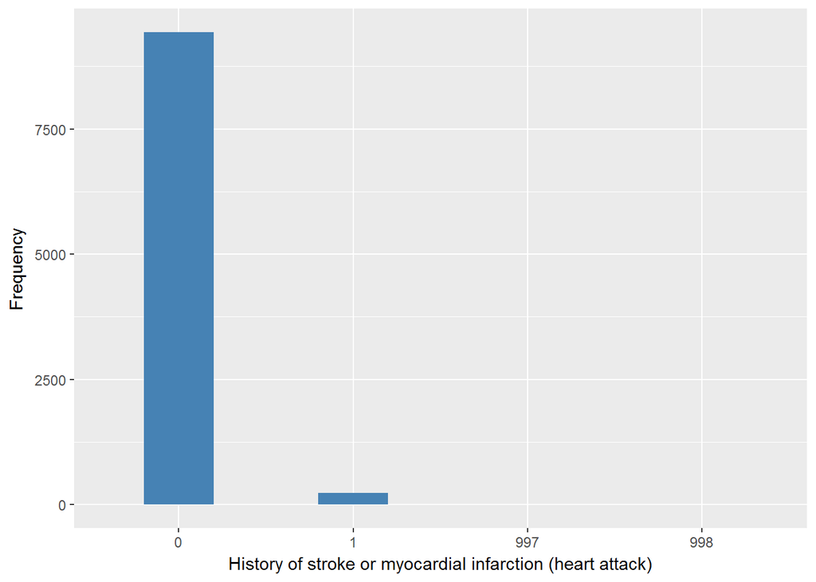

#### 2.1.7.4 Validation

|  | all 0->0 | some 1->1 | 997->997 | 998->998 |
| --- | --- | --- | --- | --- |
| BeforeH | 9430 | 230 | 1 | 5 |
| AfterH | 9430 | 230 | 1 | 5 |

## 2.2 Summary of descriptive statistics of the harmonised variable accross populations and waves

Two tables are generated:

1. Percentages of categories in each harmonised variable.
2. Frequencies and percentages of individuals with different trajectories. To avoid too large table, Only trajectories with percentages larger than 0.3 are shown.

**R script:**

```r
l.hds <- list(w1 = ELSA_ds_w1, w2 = ELSA_ds_w2, w3 = ELSA_ds_w3, w4 = ELSA_ds_w4,
    w5 = ELSA_ds_w5, w6 = ELSA_ds_w6, w7 = ELSA_ds_w7)

for (name in names(l.hds)) {
    aux_object <- l.hds[[name]]
    label(l.hds[[name]][[2]]) <- label(aux_object[[2]]) <- ds_label  # Text value assigned at the DS description, at the top
    l.hds[[name]][[2]] <- labelled(l.hds[[name]][[2]], labels = cat_label)
    aux_object[[2]] <- car::recode(aux_object[[2]], "miss_values_vector=NA")
    aux_object[[2]] <- labelled(aux_object[[2]], labels = cat_label[1:2])
    m_name <- paste0("ELSA_m_ds_", name)
    assign(m_name, aux_object)
    rm(aux_object)
}

t.hds <- frq(l.hds[[1]][2])[[1]][, c(1, 2)]
for (i in seq_along(l.hds)) {
    t.hds[2 + i] <- frq(l.hds[[i]][2])[[1]][, 4]
}
t.hds[13, ] <- c("n", "sample size", length(l.hds[[1]][[2]]), length(l.hds[[2]][[2]]),
    length(l.hds[[3]][[2]]), length(l.hds[[4]][[2]]), length(l.hds[[5]][[2]]),
    length(l.hds[[6]][[2]]), length(l.hds[[7]][[2]]))
names(t.hds) <- c("val", "label", "w1", "w2", "w3", "w4", "w5", "w6", "w7")
kable(t.hds)
```

| val | label | w1 | w2 | w3 | w4 | w5 | w6 | w7 |
| --- | --- | --- | --- | --- | --- | --- | --- | --- |
| 0 | No | 90.76 | 96.79 | 97.75 | 97.07 | 97.35 | 97.38 | 97.56 |
| 1 | Yes | 9.17 | 3.12 | 2.2 | 2.79 | 2.5 | 2.52 | 2.38 |
| 991 | CAPI interviewer error | 0 | 0 | 0 | 0 | 0 | 0 | 0 |
| 992 | Impute | 0 | 0 | 0 | 0 | 0 | 0 | 0 |
| 993 | Disable to measure | 0 | 0 | 0 | 0 | 0 | 0 | 0 |
| 994 | Not attempt not done | 0 | 0 | 0 | 0 | 0 | 0 | 0 |
| 995 | Does not answer | 0 | 0 | 0 | 0 | 0 | 0 | 0 |
| 996 | Not applicable | 0 | 0 | 0.05 | 0 | 0 | 0 | 0 |
| 997 | Refuse | 0.02 | 0.01 | 0 | 0.06 | 0.04 | 0.04 | 0.01 |
| 998 | Do not know | 0.05 | 0.08 | 0 | 0.08 | 0.11 | 0.07 | 0.05 |
| 999 | Missing | 0 | 0 | 0 | 0 | 0 | 0 | 0 |
| NA | NA | 0 | 0 | 0 | 0 | 0 | 0 | 0 |
| n | sample size | 12099 | 9432 | 9771 | 11050 | 10274 | 10601 | 9666 |

```r
dbb <- merge(ELSA_m_ds_w1[, c("id", "cvd_hard")], ELSA_m_ds_w2[, c("id", "cvd_hard")],
    by = "id", suffixes = c(".w1", ".w2"), all = T)
dbb <- merge(dbb, ELSA_m_ds_w3[, c("id", "cvd_hard")], by = "id", all = T)
dbb <- merge(dbb, ELSA_m_ds_w4[, c("id", "cvd_hard")], by = "id", suffixes = c(".w3",
    ".w4"), all = T)
dbb <- merge(dbb, ELSA_m_ds_w5[, c("id", "cvd_hard")], by = "id", all = T)
dbb <- merge(dbb, ELSA_m_ds_w6[, c("id", "cvd_hard")], by = "id", suffixes = c(".w5",
    ".w6"), all = T)
dbb <- merge(dbb, ELSA_m_ds_w7[, c("id", "cvd_hard")], by = "id", all = T)
names(dbb) <- c("id", "w1", "w2", "w4", "w5")
v.dbb <- paste(dbb[, 2], dbb[, 3], dbb[, 4], dbb[, 5], dbb[, 6], dbb[, 7], dbb[,
    8], sep = "")
f.dbb <- frq(v.dbb)[[1]][, c(1, 2, 4)]
kable(f.dbb[f.dbb[, 3] >= 0.3, ])
```

|  | val | frq | raw.prc |
| --- | --- | --- | --- |
| 1 | 0000000 | 3802 | 20.56 |
| 2 | 0000001 | 72 | 0.39 |
| 3 | 000000NA | 544 | 2.94 |
| 7 | 00000NA0 | 60 | 0.32 |
| 8 | 00000NANA | 378 | 2.04 |
| 16 | 0000NA00 | 58 | 0.31 |
| 22 | 0000NANANA | 492 | 2.66 |
| 37 | 000NA000 | 109 | 0.59 |
| 52 | 000NANANANA | 742 | 4.01 |
| 73 | 00NA0000 | 101 | 0.55 |
| 103 | 00NANANANANA | 1103 | 5.97 |
| 141 | 0NA00000 | 84 | 0.45 |
| 162 | 0NA0NANANANA | 99 | 0.54 |
| 172 | 0NANA0000 | 66 | 0.36 |
| 204 | 0NANANANANANA | 1797 | 9.72 |
| 205 | 1000000 | 176 | 0.95 |
| 239 | 100NANANANA | 105 | 0.57 |
| 265 | 10NANANANANA | 125 | 0.68 |
| 319 | 1NANANANANANA | 286 | 1.55 |
| 352 | NANA00000 | 824 | 4.46 |
| 354 | NANA0000NA | 110 | 0.59 |
| 357 | NANA000NANA | 82 | 0.44 |
| 365 | NANA00NANANA | 118 | 0.64 |
| 371 | NANA0NA000 | 55 | 0.30 |
| 386 | NANA0NANANANA | 297 | 1.61 |
| 403 | NANANA0000 | 1591 | 8.61 |
| 405 | NANANA000NA | 227 | 1.23 |
| 410 | NANANA00NANA | 171 | 0.92 |
| 423 | NANANA0NANANA | 335 | 1.81 |
| 437 | NANANANA000 | 77 | 0.42 |
| 447 | NANANANANA00 | 907 | 4.91 |
| 449 | NANANANANA0NA | 259 | 1.40 |
| 453 | NANANANANANA0 | 495 | 2.68 |

# 3 Quality estimation

It contains information about myocardial infarction and stroke.